# Healthcare

Ryosuke Kawamori

2017/12/1

## Healthcare Fraud Detection

### アイデア

- 医者と患者を世界メッシュに基づいてクラスタリングし、各メッシュごとの傾向をみる.  
  $\rightarrow$今回のデータには患者の位置情報が含まれない
- 各Provider(医者)に関して特徴量を作成、$k$-近傍法や外れ値検出

### データについて

データの各列の内容は, [こちら](https://www.cms.gov/Research-Statistics-Data-and-Systems/Statistics-Trends-and-Reports/Medicare-Provider-Charge-Data/Downloads/Medicare-Physician-and-Other-Supplier-PUF-Methodology.pdf).

#### データの大まかな特徴

Providerの種類.

Entity Type of the Providerの頻度

| EntityTypeoftheProvider | n |
| --- | --- |
| I | 95548 |
| O | 4452 |

上表より,個人として登録されているService Providerが多い. Entitye Type IndivisualのHealthcare Service 頻度について

Indivisual ProviderのHealthacare Serviceの頻度

| HCPCSCode | HCPCSDescription | n |
| --- | --- | --- |
| 99213 | Established patient office or other outpatient visit, typically 15 minutes | 4674 |
| 99214 | Established patient office or other outpatient, visit typically 25 minutes | 4065 |
| 99232 | Subsequent hospital inpatient care, typically 25 minutes per day | 1805 |
| 99203 | New patient office or other outpatient visit, typically 30 minutes | 1752 |
| 99204 | New patient office or other outpatient visit, typically 45 minutes | 1727 |
| 99212 | Established patient office or other outpatient visit, typically 10 minutes | 1658 |
| 99223 | Initial hospital inpatient care, typically 70 minutes per day | 1421 |
| 99222 | Initial hospital inpatient care, typically 50 minutes per day | 1244 |
| 99233 | Subsequent hospital inpatient care, typically 35 minutes per day | 1186 |
| 99215 | Established patient office or other outpatient, visit typically 40 minutes | 1166 |
| G0008 | Administration of influenza virus vaccine | 1096 |
| 36415 | Insertion of needle into vein for collection of blood sample | 1019 |
| 93000 | Routine EKG using at least 12 leads including interpretation and report | 915 |
| 99231 | Subsequent hospital inpatient care, typically 15 minutes per day | 834 |
| 71020 | X-ray of chest, 2 views, front and side | 673 |

上表より, 15・25分定期的外来患者の診察が多いことがわかる.

Organization の Healrthcare Service頻度

| HCPCSCode | HCPCSDescription | n |
| --- | --- | --- |
| G0008 | Administration of influenza virus vaccine | 422 |
| 90662 | Vaccine for influenza for injection into muscle | 347 |
| 90656 | Vaccine for influenza for injection into muscle, patient 3 years and older | 247 |
| G0009 | Administration of pneumococcal vaccine | 154 |
| Q2037 | Influenza virus vaccine, split virus, when administered to individuals 3 years of age and older, for intramuscular use (fluvirin) | 131 |
| A0425 | Ground mileage, per statute mile | 100 |
| 90732 | Vaccine for pneumococcal polysaccharide for injection beneath the skin or into muscle, patient 2 years or older | 96 |
| A0427 | Ambulance service, advanced life support, emergency transport, level 1 (als1-emergency) | 83 |
| A0429 | Ambulance service, basic life support, emergency transport (bls-emergency) | 76 |
| 90686 | Vaccine for influenza administered into muscle to individuals 3 years of age and older | 59 |
| A0428 | Ambulance service, basic life support, non-emergency transport, (bls) | 46 |
| 90688 | Vaccine for influenza administered into muscle to individuals 3 years of age and older | 29 |
| A0426 | Ambulance service, advanced life support, non-emergency transport, level 1 (als 1) | 28 |
| 45385 | Removal of polyps or growths of large bowel using an endoscope | 27 |
| 62311 | Injections of substances into lower or sacral spine | 25 |

上表より,インフルエンザワクチンの管理・摂取が多いことがわかる. データ数の多いIndividualを対象に、特徴量を作ることを考える.各Service(HCPCS)について申請された・支払われた額を特徴量とすることを考える.まず,件数の多いServiceについて申請・支払われた金額を特徴量にしてみる.

特徴量

| NationalProviderIdentifier | 99213_AverageMedicareAllowedAmount | 99213_AverageSubmittedChargeAmount | 99214_AverageMedicareAllowedAmount | 99214_AverageSubmittedChargeAmount |
| --- | --- | --- | --- | --- |
| 1003000142 | 69.20000 | 107.00000 | 102.27000 | 157.00000 |
| 1003000522 | 52.07229 | 60.24390 | 79.80181 | 79.85753 |
| 1003000530 | 70.39000 | 100.00000 | 104.03000 | 150.00000 |
| 1003000720 | 66.98000 | 261.20000 | 98.57000 | 370.02740 |
| 1003000753 | 78.86000 | 140.00000 | 117.27000 | 203.00000 |
| 1003000902 | 69.32000 | 120.00000 | 102.51000 | 175.00000 |
| 1003000936 | 68.93000 | 103.13953 | 101.96000 | 152.86207 |
| 1003001256 | 51.65000 | 195.32432 | 79.28000 | 298.66667 |
| 1003001363 | 75.73570 | 182.89325 | 111.85964 | 264.00000 |
| 1003001371 | 70.15000 | 125.00000 | 103.68000 | 200.00000 |
| 1003001785 | 72.88000 | 437.05368 | 107.56000 | 599.31012 |
| 1003001884 | 70.31000 | 94.00000 | 103.93000 | 138.00000 |
| 1003002049 | 83.08000 | 200.05660 | 122.19000 | 299.55882 |
| 1003002072 | 78.56000 | 259.00000 | 115.67000 | 440.00000 |
| 1003002312 | 78.48000 | 261.88172 | 115.51000 | 281.77335 |
| 1003002510 | 67.00000 | 113.00000 | 99.24000 | 171.00000 |
| 1003002627 | 73.02000 | 133.82353 | 107.80000 | 186.46575 |
| 1003002742 | 67.89000 | 167.93103 | 100.49000 | 252.76596 |
| 1003002817 | 78.80000 | 200.05908 | 115.97000 | 284.24773 |
| 1003002890 | 73.32000 | 121.01587 | 108.16000 | 175.97368 |
| 1003003153 | 78.54000 | 195.00000 | 115.63000 | 267.00000 |
| 1003003609 | 72.06625 | 147.00000 | 106.59646 | 216.00000 |
| 1003003856 | 84.37501 | 93.00000 | 124.03000 | 145.00000 |
| 1003004318 | 42.55000 | 67.84671 | 65.46000 | 103.54231 |
| 1003004771 | 73.32000 | 145.00000 | 108.16000 | 215.60811 |
| 1003005109 | 80.19000 | 125.00000 | 117.99000 | 195.00000 |
| 1003005836 | 68.06000 | 128.00000 | 100.72000 | 192.00000 |
| 1003006107 | 73.42833 | 213.20000 | 188.08600 | 552.23830 |
| 1003006198 | 77.95000 | 195.00000 | 114.69000 | 286.01031 |
| 1003006271 | 71.34000 | 90.00000 | 105.26000 | 135.00000 |
| 1003006552 | 72.88000 | 120.26316 | 107.56000 | 160.00000 |
| 1003006610 | 56.68473 | 85.47253 | 83.71000 | 133.00000 |
| 1003006651 | 50.42000 | 57.15789 | 77.51000 | 81.14286 |
| 1003006701 | 69.32000 | 81.00000 | 102.51000 | 124.00000 |
| 1003007048 | 72.55000 | 84.00000 | 107.08000 | 142.10148 |
| 1003007170 | 78.08000 | 128.00000 | 115.04000 | 180.00000 |
| 1003007204 | 119.53000 | 297.11111 | 102.91554 | 226.78788 |
| 1003007287 | 72.20000 | 82.97036 | 106.44000 | 121.79290 |
| 1003007345 | 50.06000 | 101.00000 | 77.01000 | 154.00000 |
| 1053338061 | 40.03515 | 40.18797 | 57.50071 | 59.25664 |
| 1053339739 | 57.74000 | 93.46341 | 85.39000 | 128.95187 |
| 1063452662 | 61.95000 | 146.00000 | 91.43000 | 216.80000 |
| 1073512281 | 71.81000 | 115.18519 | 106.02000 | 171.52000 |
| 1154328805 | 49.58000 | 50.00000 | 104.29000 | 192.17647 |
| 1174535454 | 74.77000 | 129.72500 | 110.27000 | 179.10156 |
| 1184957102 | 70.39000 | 110.00000 | 104.03000 | 175.00000 |
| 1215956198 | 69.32000 | 115.00000 | 102.51000 | 172.50000 |
| 1255394482 | 70.31000 | 198.00000 | 103.93000 | 290.00000 |
| 1275568933 | 71.90719 | 154.50000 | 77.51000 | 89.89130 |
| 1285764647 | 59.99134 | 60.19530 | 89.13353 | 89.66000 |
| 1306043211 | 51.29000 | 108.08657 | 107.08000 | 158.60000 |
| 1336266105 | 72.88000 | 181.00000 | 79.94000 | 274.00000 |
| 1366420648 | 61.67000 | 80.00000 | 91.02000 | 116.00000 |
| 1366440273 | 69.86000 | 100.00000 | 103.28000 | 160.00000 |
| 1396758652 | 68.79000 | 140.00000 | 101.78000 | 165.00000 |
| 1487646980 | 57.53000 | 137.25581 | 85.17000 | 206.56667 |
| 1508062217 | 69.65000 | 81.07872 | 102.75000 | 120.11072 |
| 1508898222 | 72.88000 | 128.00000 | 107.56000 | 187.00000 |
| 1609885284 | 62.81000 | 74.02061 | 93.00000 | 110.91655 |
| 1659359164 | 68.90000 | 102.21891 | 101.85000 | 146.00000 |
| 1669481040 | 50.06000 | 101.00000 | 77.01000 | 154.00000 |
| 1679552582 | 75.15000 | 173.86897 | 110.80000 | 261.52174 |
| 1679654909 | 62.20116 | 99.98710 | 91.94000 | 147.00000 |
| 1750549309 | 50.77000 | 91.00000 | 104.36000 | 233.33333 |
| 1770570657 | 50.74000 | 185.00000 | 77.94000 | 273.00000 |
| 1811125081 | 78.48000 | 160.00000 | 115.51000 | 240.00000 |
| 1811926017 | 70.46000 | 201.00000 | 104.12000 | 299.00000 |
| 1821076837 | 61.12000 | 168.57143 | 90.21000 | 250.18045 |
| 1821264169 | 49.18000 | 160.00000 | 75.56000 | 216.00000 |
| 1841289196 | 67.68000 | 100.00000 | 100.20000 | 150.00000 |
| 1841388378 | 53.49000 | 57.00000 | 81.95000 | 87.00000 |
| 1871848770 | 42.08000 | 116.00000 | 64.67000 | 163.00000 |
| 1881647071 | 67.82934 | 135.36709 | 100.30343 | 201.05839 |
| 1881662567 | 70.39000 | 110.00000 | 104.03000 | 175.00000 |
| 1912957101 | 68.22000 | 108.00000 | 100.86000 | 145.97778 |

欠損値を取り除く処理を行うと, 行数がかなり少なくなってしまった.これは,ほとんどのProviderが15・25分どちらか片方の申請を 行なっていることを意味する.今回この欠損値は金額がないことを示すので０で埋めて良いと考えられる.0で埋めて特徴量ベクトルとする. 散布図にして図示してみる.

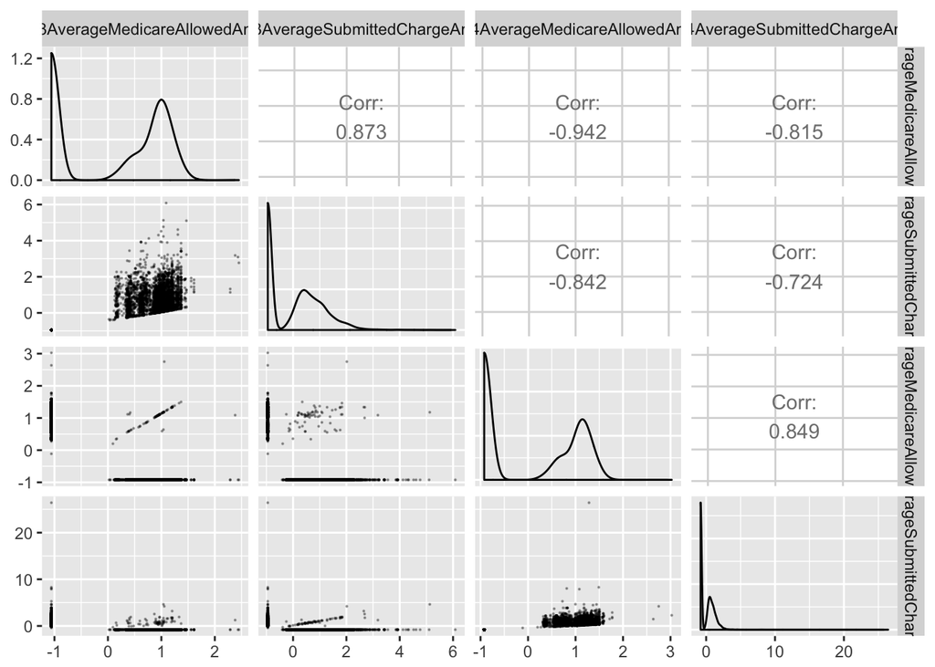

さらに、特徴量を増やして図示してみる.

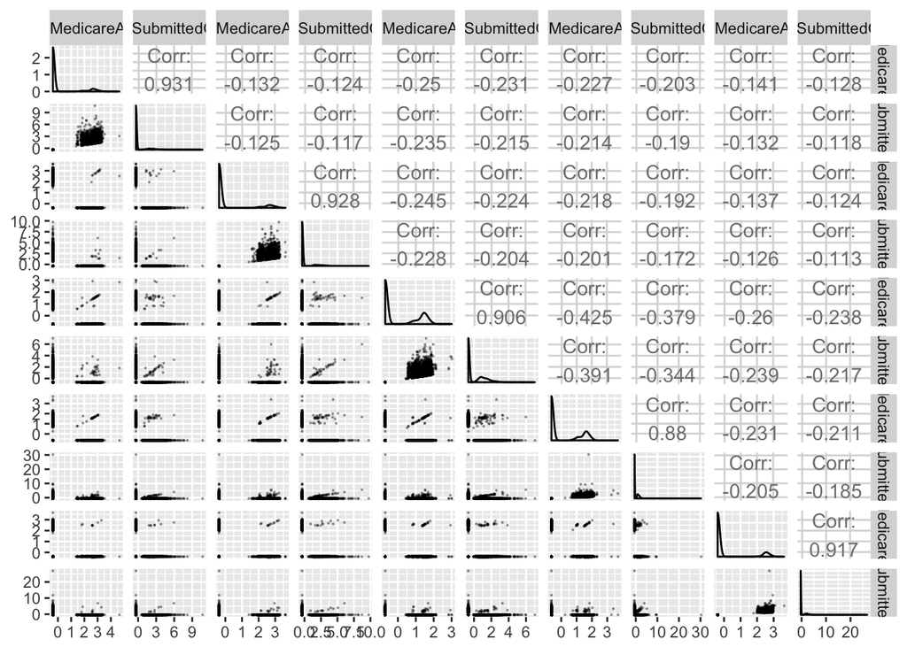

外れ値っぽいものは見られるが,これらがFraudなのだろか.

#### How much money are spent and How many services are provided?

How much money are spent and How many services are provided on what kind of service?

| HCPCSCode | HCPCSDescription | SumofAllowedAmount | NumberOfServices |
| --- | --- | --- | --- |
| 99214 | Established patient office or other outpatient, visit typically 25 minutes | 103372025 | 995699.0 |
| 99213 | Established patient office or other outpatient visit, typically 15 minutes | 77040064 | 1097964.2 |
| 99232 | Subsequent hospital inpatient care, typically 25 minutes per day | 36287515 | 499601.0 |
| A0427 | Ambulance service, advanced life support, emergency transport, level 1 (als1-emergency) | 31861910 | 74833.0 |
| J2778 | Injection, ranibizumab, 0.1 mg | 28987158 | 73057.0 |
| 66984 | Removal of cataract with insertion of lens | 25794394 | 78497.0 |
| 99233 | Subsequent hospital inpatient care, typically 35 minutes per day | 23157450 | 220914.0 |
| 99285 | Emergency department visit, problem with significant threat to life or function | 21860608 | 126022.0 |
| 99223 | Initial hospital inpatient care, typically 70 minutes per day | 21626278 | 105955.0 |
| A0428 | Ambulance service, basic life support, non-emergency transport, (bls) | 18564281 | 87187.0 |
| 92014 | Eye and medical examination for diagnosis and treatment, established patient, 1 or more visits | 16864555 | 135368.0 |
| 99204 | New patient office or other outpatient visit, typically 45 minutes | 13883013 | 85952.0 |
| 99291 | Critical care delivery critically ill or injured patient, first 30-74 minutes | 13168295 | 58205.0 |
| 99215 | Established patient office or other outpatient, visit typically 40 minutes | 12816987 | 92347.0 |
| J0178 | Injection, aflibercept, 1 mg | 12411709 | 12668.0 |
| 97110 | Therapeutic exercise to develop strength, endurance, range of motion, and flexibility, each 15 minutes | 12348200 | 454176.3 |
| A0425 | Ground mileage, per statute mile | 12074538 | 1474382.6 |
| 99203 | New patient office or other outpatient visit, typically 30 minutes | 10733888 | 102992.0 |
| 99222 | Initial hospital inpatient care, typically 50 minutes per day | 10651538 | 76788.0 |
| 88305 | Pathology examination of tissue using a microscope, intermediate complexity | 10628796 | 228802.2 |

#### Visualized Answers to Hackathon Challenges.

1.How many phsycians from each state?

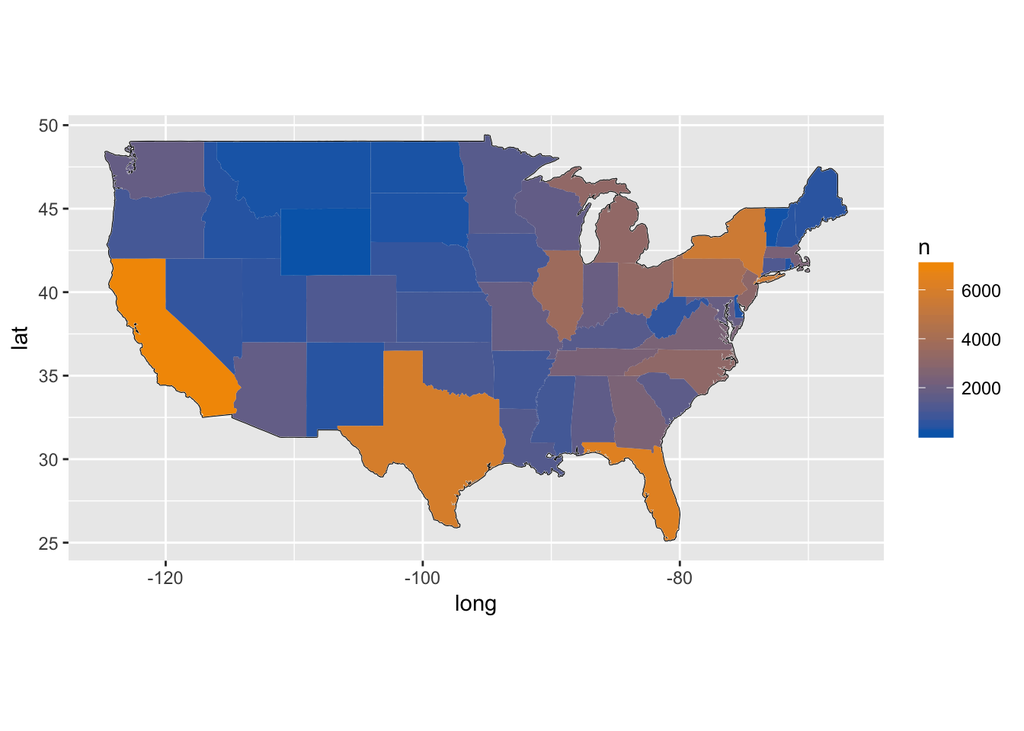

2.How many specializations out of how many physicians?

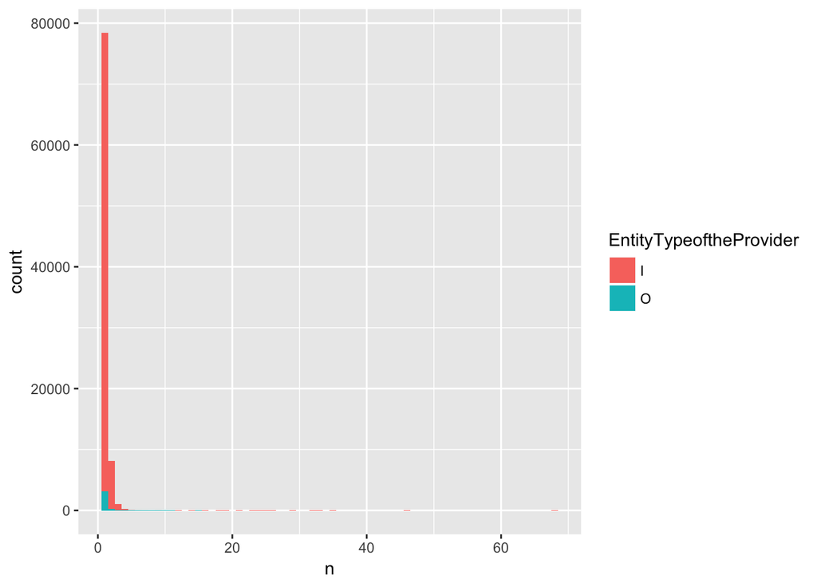

3.Map anomalies or missing data across the country or within states or counties or electoral districts.

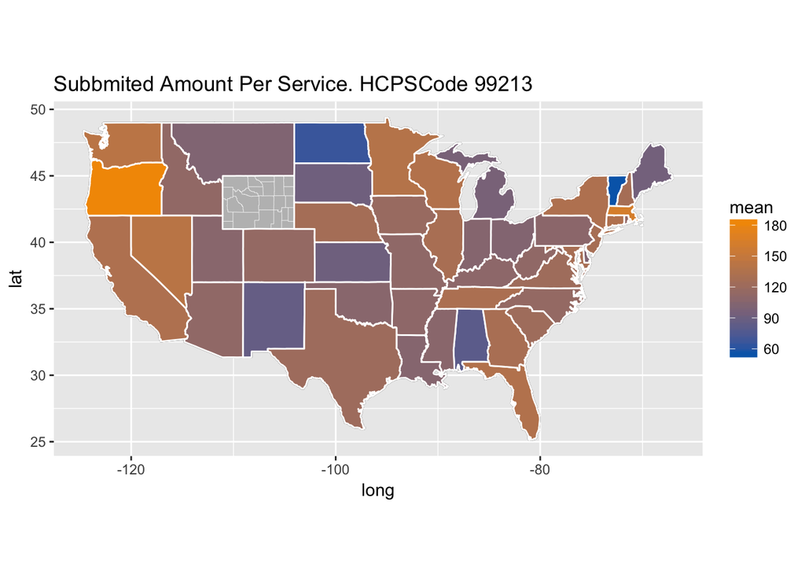

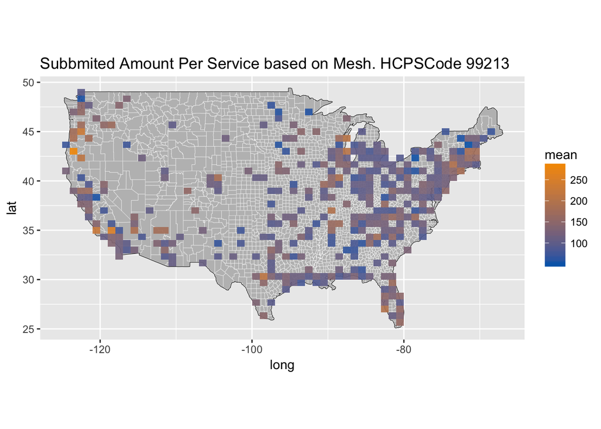

It seems that there are some geographical dependencies.

#### How much money are spent on What kind of Provider?

| ProviderTypeoftheProvider | AllowedAmount | AAmean | AAsd | NumofServices | NoSmean | NoSsd | n |
| --- | --- | --- | --- | --- | --- | --- | --- |
| Internal Medicine | 119182453 | 9492.072 | 21570.459 | 1990945.1 | 158.56524 | 928.5429 | 12556 |
| Ophthalmology | 100935342 | 39535.974 | 192629.262 | 651557.0 | 255.21230 | 635.8639 | 2553 |
| Ambulance Service Supplier | 86729884 | 233144.850 | 630312.765 | 1823849.2 | 4902.82043 | 24935.0569 | 372 |
| Cardiology | 68460357 | 12355.235 | 31841.172 | 880165.3 | 158.84593 | 390.8398 | 5541 |
| Family Practice | 65762007 | 6387.762 | 17230.036 | 1221316.1 | 118.63197 | 372.4279 | 10295 |
| Clinical Laboratory | 46999191 | 34660.170 | 152764.193 | 3124020.3 | 2303.84978 | 11210.6673 | 1356 |
| Diagnostic Radiology | 41986617 | 3264.900 | 7732.758 | 1424474.5 | 110.76785 | 878.8303 | 12860 |
| Ambulatory Surgical Center | 37540113 | 61440.447 | 175269.940 | 68083.0 | 111.42881 | 236.3458 | 611 |
| Hematology/Oncology | 35058851 | 19220.862 | 54536.264 | 1850355.0 | 1014.44901 | 5188.5352 | 1824 |
| Emergency Medicine | 32760260 | 13684.319 | 22140.694 | 292003.0 | 121.97285 | 162.8385 | 2394 |
| Dermatology | 31642006 | 15750.127 | 36469.169 | 443790.0 | 220.90095 | 626.2122 | 2009 |
| Orthopedic Surgery | 29069502 | 8572.546 | 14731.619 | 440538.0 | 129.91389 | 392.1808 | 3391 |
| Radiation Oncology | 25245133 | 29354.806 | 164906.471 | 150073.0 | 174.50349 | 480.9973 | 860 |
| Nephrology | 24464069 | 20697.182 | 44014.644 | 291985.0 | 247.02623 | 1177.4514 | 1182 |
| Nurse Practitioner | 23483735 | 6093.341 | 15598.550 | 459685.1 | 119.27481 | 424.9753 | 3854 |
| Physical Therapist | 23478281 | 10735.382 | 16347.970 | 875585.3 | 400.35908 | 608.0191 | 2187 |
| Podiatry | 20188892 | 9999.451 | 19276.826 | 352073.0 | 174.37989 | 332.7195 | 2019 |
| Gastroenterology | 18492837 | 9769.063 | 14222.282 | 161175.0 | 85.14263 | 213.6737 | 1893 |
| Urology | 18254226 | 9168.371 | 18057.403 | 324730.5 | 163.09920 | 535.6028 | 1991 |
| Pulmonary Disease | 18054158 | 11964.319 | 23791.950 | 210543.0 | 139.52485 | 274.2952 | 1509 |

#### Are there provides which provides many kinds of servise and receive much money?

Arranged by Sum of Medicare Allowed Amount.

| NationalProviderIdentifier | EntityTypeoftheProvider | ProviderTypeoftheProvider | n | SumofMedicareAllowedAmount | TotalNumberofServices |
| --- | --- | --- | --- | --- | --- |
| 1003006180 | O | Ambulance Service Supplier | 7 | 6920670 | 101736.7 |
| 1477663839 | O | Ambulance Service Supplier | 1 | 6141770 | 14112.0 |
| 1184762577 | I | Ophthalmology | 1 | 5287464 | 13326.0 |
| 1801892146 | I | Ophthalmology | 1 | 4986861 | 12568.0 |
| 1629209853 | O | Clinical Laboratory | 4 | 4236342 | 236306.0 |
| 1558356444 | O | Ambulance Service Supplier | 1 | 3654558 | 400446.5 |
| 1063604692 | I | Radiation Oncology | 1 | 3606873 | 3703.0 |
| 1932153335 | O | Ambulance Service Supplier | 1 | 3416120 | 16286.0 |
| 1326094020 | O | Ambulance Service Supplier | 1 | 3123888 | 690.0 |
| 1275621716 | O | Ambulance Service Supplier | 1 | 3123687 | 6955.0 |
| 1336138635 | O | Ambulatory Surgical Center | 1 | 2783250 | 2746.0 |
| 1780678029 | I | Ophthalmology | 1 | 2651889 | 6683.0 |
| 1932396348 | O | Ambulance Service Supplier | 1 | 2608980 | 11430.0 |
| 1073543021 | O | Ambulance Service Supplier | 1 | 2579644 | 12461.0 |
| 1235172446 | I | Radiation Oncology | 1 | 2407999 | 1001.0 |
| 1457338162 | I | Ophthalmology | 1 | 2387525 | 6017.0 |
| 1649265638 | I | Ophthalmology | 2 | 2019798 | 2083.0 |
| 1982759221 | I | Ophthalmology | 1 | 1978159 | 4985.0 |
| 1841203429 | O | Clinical Laboratory | 3 | 1941043 | 6153.0 |
| 1750364345 | O | Clinical Laboratory | 5 | 1908096 | 16467.0 |

Arranged by Number of services which provider provide

| NationalProviderIdentifier | EntityTypeoftheProvider | ProviderTypeoftheProvider | n | SumofMedicareAllowedAmount | TotalNumberofServices |
| --- | --- | --- | --- | --- | --- |
| 1003002809 | I | Diagnostic Radiology | 68 | 854539.99 | 5004 |
| 1003006636 | I | Diagnostic Radiology | 46 | 147344.63 | 7147 |
| 1003007170 | I | Cardiology | 35 | 382896.44 | 3922 |
| 1003006107 | I | Cardiology | 33 | 272633.31 | 7861 |
| 1003007048 | I | Family Practice | 32 | 101300.51 | 3152 |
| 1003001363 | I | Anesthesiology | 29 | 903780.11 | 20860 |
| 1003002783 | I | Diagnostic Radiology | 29 | 116676.79 | 2504 |
| 1003007204 | I | Cardiology | 26 | 250970.34 | 2740 |
| 1003002742 | I | Physical Medicine and Rehabilitation | 25 | 143959.40 | 3160 |
| 1003000936 | I | Internal Medicine | 24 | 252562.12 | 3305 |
| 1003003856 | I | Family Practice | 23 | 120927.34 | 2727 |
| 1003006552 | I | Family Practice | 23 | 306611.41 | 3513 |
| 1003007287 | I | Internal Medicine | 21 | 52184.02 | 1177 |
| 1003002072 | I | Urology | 19 | 137808.77 | 1399 |
| 1003002312 | I | Internal Medicine | 19 | 897292.10 | 13457 |
| 1003005257 | I | Pathology | 19 | 56409.08 | 1696 |
| 1003000407 | I | Family Practice | 18 | 101543.31 | 918 |
| 1003001884 | I | Family Practice | 16 | 42474.33 | 645 |
| 1003002627 | I | Obstetrics/Gynecology | 16 | 62187.95 | 784 |
| 1003000522 | I | Family Practice | 15 | 114587.41 | 1555 |

What does it mean to have a not integer number of services…?

#### Does the Submitted amount on the same HCPCSCode have large variance?

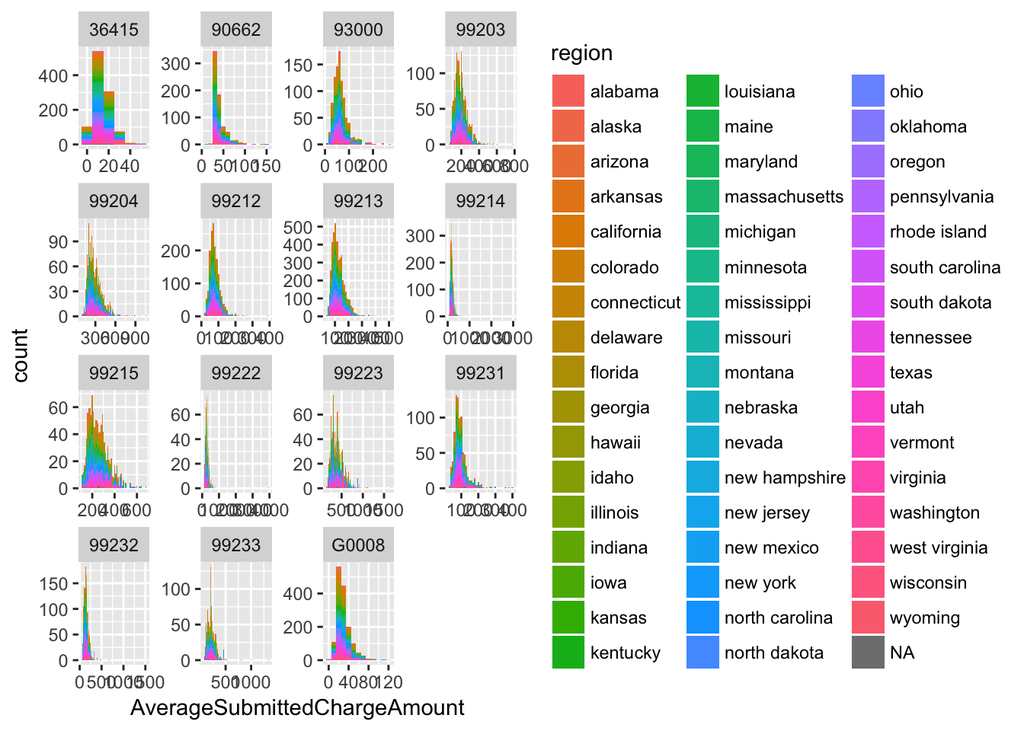